Skip to main content

# Northeast Fire & Weather Data Assessment

Fire occurrence, ignition-day fire danger, burn windows, and data gaps in the USDA Northeast Climate Hub region

Author

Carver Rasmussen

Published

November 25, 2026

## Summary

- Northeast wildfires are a spring problem. 52.8% of the 235,312 fires in the cleaned 1992–2024 record were discovered in March–May.
- Fires of 10 acres or more start on unusually dry days. The median fire started at the 84th percentile of its own location’s energy release component (ERC) for that time of year.
- Prescribed-burn windows are rare, and the limits are the same as in the Pacific Northwest: humidity and wind, not temperature. The window was open 8.7% of hours at six RAWS stations in 2025.
- The main data gap is small fires. 99.8% of fires, carrying 55.2% of burned area, are below the size MTBS maps in the East.

## Q1. When and where do Northeast wildfires happen?

**52.8% of fires were discovered in March–May, and April alone accounts for 26.1%.** Every state peaks in March or April, before leaf-out (Figure 1). A smaller second peak falls in November.

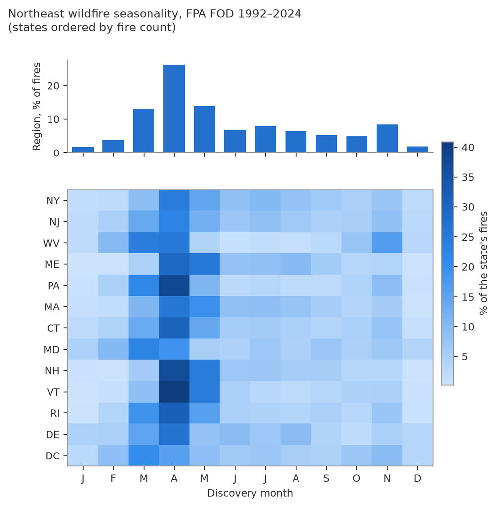

Figure 1: Share of each state’s fires by discovery month, 1992–2024. Top: whole region.

**Almost all fires are small.** 99.8% were under 500 acres. Those fires still burned 55.2% of the area.

**People start nearly all of them.** Only 4.2% had a natural cause. The most common known causes were debris and open burning (17.7%) and arson/incendiarism (16.1%). The cause was missing or undetermined for 32.8%.

**Reported fire density is highest in New Jersey’s Pine Barrens, on Long Island, and in southern West Virginia** (Figure 2). Counts depend heavily on how each state reports (see Q4), so this map shows reported fires, not fire risk.

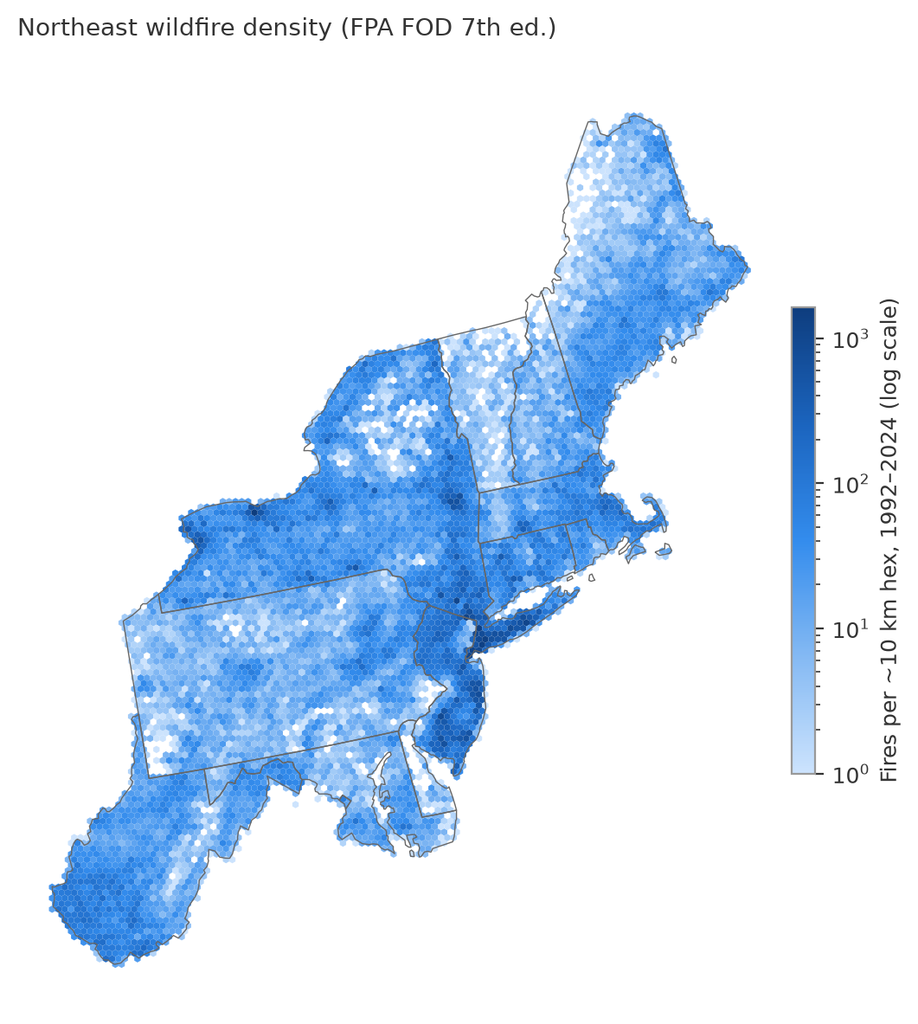

Figure 2: Reported wildfires per ~10 km hexagon, 1992–2024 (log scale).

QA removed 4,359 likely duplicate records: same day, same ~1 km location, same size. It also flagged 923 points that fall outside their reported state.

## Q2. What were fire-danger conditions at ignition?

**87.4% of fires of 10 acres or more started on days with ERC above their location’s median for that time of year.** The median fire sat at the 84.4th percentile. 100-hour fuel moisture agrees: the median fire started at the 16.6th percentile, so fuels were drier than usual. A one-sided sign test rejects “no difference from normal” for both (p < 0.001).

**Spring fires are not more extreme than summer or fall fires.** The median ERC percentile was 83.5 in spring (n = 5,732) and 86.0 in summer/fall (n = 3,147). Spring has more fires because more fuel is exposed and dry before leaf-out. In every season, fires still need an unusually dry day.

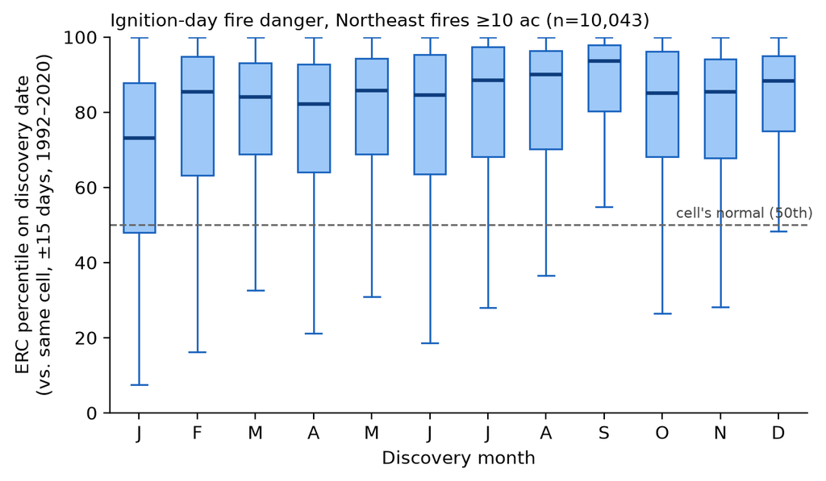

Figure 3: ERC percentile on the discovery date, by month. Each fire is compared with its own gridMET cell, ±15 days, 1992–2020.

**The result holds in every state.** State median ERC percentiles range from 77.5 to 91.8. West Virginia supplies 61% of these fires, so the regional numbers lean on it. The per-state table shows the pattern does not depend on WV.

Method: 10,046 fires of 10 acres or more were matched to 4,220 gridMET cells; 3 fell outside the grid. Each fire’s discovery-day value was ranked against the same cell’s values within ±15 days of that date across 1992–2020.

## Q3. What limits prescribed-burn windows in the Northeast?

**The burn window was open 8.7% of hours across six RAWS stations in 2025.** Thresholds are Northeast timber-fuel medians from a survey of 31 burn plans (Fast, Ducey & Weyrick, UNH Cooperative Extension): RH 30–67 %, 20-ft wind 4.5–20 mph, temperature 35–87.5 °F, no measurable rain in the past 24 h.

**The binding constraints match the PNW: wind and humidity.** Wind failed 64.2% of hours and RH 61.5%. The direction matters. Wind failures were too calm (33,500 h), not too strong (12 h). RH failures were too humid (30,320 h), not too dry (1,795 h). Northeast windows close because the air is still and damp.

**The temperature ceiling almost never binds, as in the PNW.** Only 708 of 15,507 temperature-failure hours were too hot. The rest (14,799 h) were below the 35 °F floor, which the PNW prescription does not have.

**Window hours peak in March (624 h) and April (578 h)**, the same months fires peak. The conditions that allow a controlled burn overlap with the conditions under which wildfires start.

Code and station details: fire-weather-windows, region `northeast`.

## Q4. Where are the data gaps?

Table 1: Main fire and weather datasets for the Northeast. Sources in the last column; Northeast numbers from this project’s CSVs.

| Dataset | What it measures | Resolution | Coverage / latency | Northeast limitations | Who it serves | Source |
| --- | --- | --- | --- | --- | --- | --- |
| FPA FOD 7th ed. | One point per reported wildfire: discovery date, final size, cause, location | Point; location at least as precise as a PLSS section (~2.6 km²) | 1992–2024; published 2026 (~1.5 yr after last fire year) | Counts follow state reporting systems, not fire activity (see a_annual_by_state.csv); ends 2024 | Fire occurrence research, FPA planning, risk modeling | Short 2026, doi:10.2737/RDS-2013-0009.7; Short 2014 ESSD |
| State fire reporting systems (inputs to FPA FOD) | Fires responded to by state forestry agencies | Point or town/section, varies by state | Varies by state; reaches FPA FOD with the next edition | Reporting starts and stops by state; DE reports 0–39 fires/yr across 1992–2024 | State fire agencies, NASF, FPA FOD compilers | figures/a_annual_by_state.csv; FPA FOD SOURCE_SYSTEM fields |
| gridMET | Daily surface weather and NFDRS fire-danger indices (ERC, BI, FM100, FM1000) | ~4 km (1/24°) grid | 1979–present, CONUS, updated daily; recent days provisional | One value per 4 km cell vs. point fires; ERC is computed for a single NFDRS fuel model (G) everywhere | Researchers, drought and fire-danger monitoring | Abatzoglou 2013, Int. J. Climatol. 33:121–131; climatologylab.org/gridmet |
| RAWS (via USFS FEMS) | Hourly temperature, RH, wind, precipitation, solar radiation, with QC flags | Station point | Hourly, near real-time; full period of record in FEMS | 100 active stations across 12 states; none in CT, DE | Fire managers (NFDRS, burn planning), fire-weather forecasters | FEMS Climatology API External User Guide (2025); data/reference/ne_raws_stations_fems.csv |
| MTBS | Burn perimeters and burn severity for large fires | 30 m (Landsat; Sentinel-2 resampled to 30 m) | 1984–present; typically released 6–12 months after the fire, quarterly releases | Maps only fires ≥500 ac in the East; 99.8% of NE fires (55.2% of NE acres) fall below that | Fire effects research, LANDFIRE, land managers | mtbs.gov (project overview, data availability); USGS EROS MTBS page |
| NASA FIRMS (MODIS, VIIRS) | Satellite active-fire (thermal anomaly) detections | MODIS 1 km; VIIRS 375 m | Near real-time, within 3 h of observation; archive available | Misses fires between overpasses or under cloud, smoke or tree canopy; small, cool fires missed by MODIS | Incident awareness, alerts, global fire monitoring | FIRMS Fire Alerts notes; NASA Earthdata VIIRS 375 m page |

**Two states have no fire-weather station, and coverage is thin in northern New England.** FEMS lists 100 active RAWS stations across the 12 states. CT and DE have none. Among states with stations, density runs from 0.63 to 5.25 per 10,000 km² of land (Figure 4).

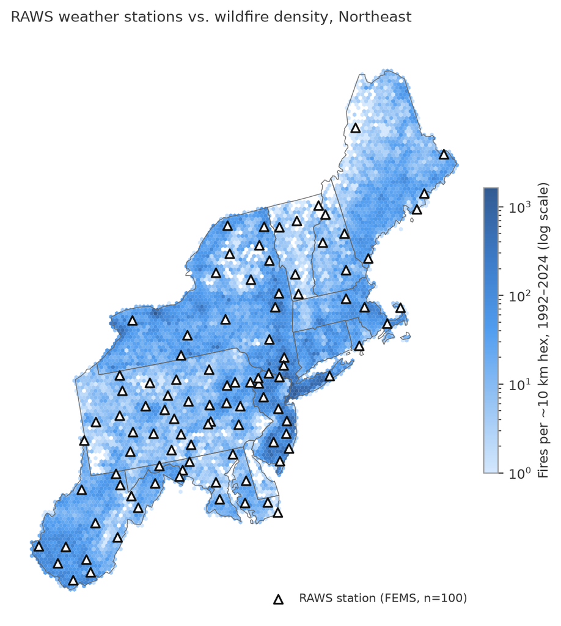

Figure 4: FEMS RAWS stations over reported fire density.

**State reporting changes over time.** New York reported 107 to 7,546 fires per year. Delaware never reported more than 39. Swings this large follow reporting systems, not fire activity, so this project does not report fire-count trends.

### Data needs

1. **Small-fire perimeters.** 55.2% of Northeast burned area is in fires MTBS does not map. A small-fire burned-area product would cover more than half of the region’s fire footprint.
2. **A consistent state reporting record.** New York’s annual count ranges 107–7,546, and Delaware’s tops out at 39. Trend analysis needs a continuous, documented record from each state.
3. **More fire-weather stations.** CT and DE have no RAWS, and Maine has 0.63 stations per 10,000 km². Pulling other mesonet stations into FEMS would help burn planning and NFDRS.
4. **Transport wind and smoke-dispersion data for burn planning.** Wind was the sole reason a window closed in 11.1% of hours, almost always because it was too calm. Mixing height and transport wind would show whether those calm hours are truly unusable.
5. **Updated Northeast prescriptions.** The thresholds here come from a 2008 survey with few timber plans. ERC already separates fire days well (median 84th percentile), so a current, shared prescription database would let these tools run on agreed numbers.

## Limitations

- **FPA FOD ends in 2024.** This project uses the 7th edition (1992–2024). Fires from 2025 onward are not included.
- **State reporting gaps.** Counts reflect each state’s reporting system. Delaware’s record is nearly empty and New York’s changes by more than tenfold. Seasonality and size results are pooled across years and are less affected than counts.
- **gridMET cells vs. point fires.** Each fire is scored on a ~4 km cell. A fire point is not a cell average. Discovery date can lag ignition. gridMET ERC uses one fuel model (G) everywhere.
- **Few Northeast RAWS.** Part C uses six stations and one year (2025). Results describe those sites, not every forest type. FEMS QC flags were blank for recent hours, so some unflagged errors may remain.
- **Thresholds source.** The Northeast prescription is a set of medians from a 2008 survey, with 8–17 timber plans per parameter. Real burn plans vary by site and objective.
- **Part B leans on West Virginia**, which supplies most fires of 10 acres or more. Per-state medians are reported to check this.
- **Station density uses land area, not forest area**, and DC is excluded because it was not in the station query.

## Sources

- Short, K.C. 2026. Spatial wildfire occurrence data for the United States, 1992–2024 [FPA_FOD_20260615]. 7th ed. USFS Research Data Archive. doi:10.2737/RDS-2013-0009.7
- Abatzoglou, J.T. 2013. Development of gridded surface meteorological data for ecological applications and modelling. Int. J. Climatol. 33:121–131.
- Fast, A.J., Ducey, M.J., Weyrick, R.R. Common Prescribed Burning Prescription Parameters in Northeastern Fuels. UNH Cooperative Extension.
- USFS Fire Environment Mapping System (FEMS), Climatology API External User Guide (2025).
- MTBS (mtbs.gov); USGS EROS. NASA FIRMS (firms.modaps.eosdis.nasa.gov).
- Every method choice: `docs/decision_log.md`.